# R Notebook

```r
library(tidyverse)
library(lubridate)
```

The Dataset YERockfish.csv contains measurements of fish collected from along the Oregon coast

Yelloweye Rockfish (Sebastes rubberimus) Length (length; to the nearest cm),

Age (years)

Maturity (Immature and Mature) state of female

Read in the data as a tibble

```r
fish_data = as_tibble(YERockfish, sep = "\t", header = TRUE)
fish_data
```

| date | length | age | maturity | stage |
| --- | --- | --- | --- | --- |
| 9/2/2003 | 31 | 10 | Immature | 1 |
| 10/7/2002 | 32 | 6 | Immature | 1 |
| 7/18/2000 | 32 | 11 | Immature | 1 |
| 6/11/2001 | 32 | 11 | Immature | 2 |
| 8/8/2000 | 32 | 13 | Immature | 2 |
| 10/4/2003 | 33 | 9 | Immature | 1 |
| 7/17/2000 | 33 | 10 | Immature | 1 |
| 8/18/2002 | 34 | 8 | Immature | 1 |
| 7/12/2000 | 34 | 10 | Immature | 1 |
| 7/25/2000 | 34 | 11 | Immature | 1 |

[output cut: 148 more lines]

This data contains a date column. R provides an easy way to manipulate dates.

The field needs to be converted to a format that R will recognize as a date. The as.POSIXct() function does this conversion. The function takes two arguments The column to convert Format of the date. Since dates come in vairous shapes (ex. yyyy/m/d, mm/dd/yy, etc..) Use the function as.POSIXct() to convert the date. The approach is exactly the same as converting to factor (as.factor()) or integer (as.integer())

Here you can pass the following format string for the parameter format

%m/%d/%Y Bonus: use a dplyr pipeline to mutate the column

```r
?add_column
```

```r
new_date <- as.Date(fish_data$date, "%m/%d/%Y")
new_fish_data <- add_column(fish_data, new_date, .before = 2)

fish_data_date = subset(new_fish_data, select = -c(date))

head(fish_data_date)
```

| new_date | length | age | maturity | stage |
| --- | --- | --- | --- | --- |
| 2003-09-02 | 31 | 10 | Immature | 1 |
| 2002-10-07 | 32 | 6 | Immature | 1 |
| 2000-07-18 | 32 | 11 | Immature | 1 |
| 2001-06-11 | 32 | 11 | Immature | 2 |
| 2000-08-08 | 32 | 13 | Immature | 2 |
| 2003-10-04 | 33 | 9 | Immature | 1 |

```r
correct_date = as.POSIXct(fish_data_date$new_date, "%Y-%m-%d")
correct_date
```

```
  [1] "2003-09-01 14:00:00 HST" "2002-10-06 14:00:00 HST" "2000-07-17 14:00:00 HST"
  [4] "2001-06-10 14:00:00 HST" "2000-08-07 14:00:00 HST" "2003-10-03 14:00:00 HST"
  [7] "2000-07-16 14:00:00 HST" "2002-08-17 14:00:00 HST" "2000-07-11 14:00:00 HST"
 [10] "2000-07-24 14:00:00 HST" "2000-07-16 14:00:00 HST" "2002-07-12 14:00:00 HST"
 [13] "2000-07-16 14:00:00 HST" "2000-08-05 14:00:00 HST" "2003-07-15 14:00:00 HST"
 [16] "2000-07-24 14:00:00 HST" "2003-08-26 14:00:00 HST" "2000-07-17 14:00:00 HST"
 [19] "2000-07-24 14:00:00 HST" "2000-05-12 14:00:00 HST" "2002-06-20 14:00:00 HST"
 [22] "2002-06-02 14:00:00 HST" "2000-08-11 14:00:00 HST" "2000-07-17 14:00:00 HST"
 [25] "2002-06-20 14:00:00 HST" "2002-06-15 14:00:00 HST" "2003-10-02 14:00:00 HST"
 [28] "2000-08-05 14:00:00 HST" "2000-05-12 14:00:00 HST" "2002-08-29 14:00:00 HST"
 [31] "2002-06-20 14:00:00 HST" "2001-06-10 14:00:00 HST" "2003-08-30 14:00:00 HST"
 [34] "2001-06-10 14:00:00 HST" "2002-10-05 14:00:00 HST" "2003-10-05 14:00:00 HST"
 [37] "2002-06-02 14:00:00 HST" "2003-08-26 14:00:00 HST" "2000-05-09 14:00:00 HST"
 [40] "2000-05-12 14:00:00 HST" "2000-07-17 14:00:00 HST" "2002-08-17 14:00:00 HST"
 [43] "2001-05-20 14:00:00 HST" "2003-06-08 14:00:00 HST" "2002-05-25 14:00:00 HST"
```

[output cut: 38 more lines]

```r
correct_date_data <- add_column(fish_data_date, correct_date, .before = 2)
correct_date_data
```

| new_date | correct_date | length | age | maturity | stage |
| --- | --- | --- | --- | --- | --- |
| 2003-09-02 | 2003-09-01 14:00:00 | 31 | 10 | Immature | 1 |
| 2002-10-07 | 2002-10-06 14:00:00 | 32 | 6 | Immature | 1 |
| 2000-07-18 | 2000-07-17 14:00:00 | 32 | 11 | Immature | 1 |
| 2001-06-11 | 2001-06-10 14:00:00 | 32 | 11 | Immature | 2 |
| 2000-08-08 | 2000-08-07 14:00:00 | 32 | 13 | Immature | 2 |
| 2003-10-04 | 2003-10-03 14:00:00 | 33 | 9 | Immature | 1 |
| 2000-07-17 | 2000-07-16 14:00:00 | 33 | 10 | Immature | 1 |
| 2002-08-18 | 2002-08-17 14:00:00 | 34 | 8 | Immature | 1 |
| 2000-07-12 | 2000-07-11 14:00:00 | 34 | 10 | Immature | 1 |
| 2000-07-25 | 2000-07-24 14:00:00 | 34 | 11 | Immature | 1 |

[output cut: 148 more lines]

```r
correct_fish_data = subset(correct_date_data, select = -c(new_date))
head(correct_fish_data)
```

| correct_date | length | age | maturity | stage |
| --- | --- | --- | --- | --- |
| 2003-09-01 14:00:00 | 31 | 10 | Immature | 1 |
| 2002-10-06 14:00:00 | 32 | 6 | Immature | 1 |
| 2000-07-17 14:00:00 | 32 | 11 | Immature | 1 |
| 2001-06-10 14:00:00 | 32 | 11 | Immature | 2 |
| 2000-08-07 14:00:00 | 32 | 13 | Immature | 2 |
| 2003-10-03 14:00:00 | 33 | 9 | Immature | 1 |

Use the function head() on your modified tibble to make sure the column is now of type dttm (date and time) instead of char

```r
head(correct_fish_data)
```

| correct_date | length | age | maturity | stage |
| --- | --- | --- | --- | --- |
| 2003-09-01 14:00:00 | 31 | 10 | Immature | 1 |
| 2002-10-06 14:00:00 | 32 | 6 | Immature | 1 |
| 2000-07-17 14:00:00 | 32 | 11 | Immature | 1 |
| 2001-06-10 14:00:00 | 32 | 11 | Immature | 2 |
| 2000-08-07 14:00:00 | 32 | 13 | Immature | 2 |
| 2003-10-03 14:00:00 | 33 | 9 | Immature | 1 |

Count the number of lines in your file

```r
count(correct_fish_data)
```

| n |
| --- |
| 158 |

Plot the count of observations per year.

Note that you can easily parse the year from the data using the year() function, which takes a column of dttm datatype The function year is part of the lubridate package, which you may need to import Hint 1: try the function year() on your date column

Hint 2: Use group by to group the data and n() to count the number of entries in each group

Bonus: use a dplyr pipeline to answer this question.

```r
#Try year() on the date colum
date_year = year(correct_fish_data$correct_date)
date_year
```

```
  [1] 2003 2002 2000 2001 2000 2003 2000 2002 2000 2000 2000 2002 2000 2000 2003 2000 2003 2000
 [19] 2000 2000 2002 2002 2000 2000 2002 2002 2003 2000 2000 2002 2002 2001 2003 2001 2002 2003
 [37] 2002 2003 2000 2000 2000 2002 2001 2003 2002 2003 2003 2000 2000 2003 2002 2000 2003 2000
 [55] 2001 2001 2002 2002 2002 2002 2003 2003 2002 2002 2002 2003 2001 2002 2001 2003 2002 2003
 [73] 2000 2000 2003 2000 2000 2003 2003 2000 2003 2000 2000 2002 2003 2002 2002 2002 2002 2003
 [91] 2003 2002 2002 2004 2003 2000 2001 2008 2002 2002 2002 2002 2001 2000 2003 2003 2002 2003
[109] 2002 2002 2000 2002 2000 2002 2002 2003 2003 2002 2002 2003 2003 2002 2002 2003 2002 2002
[127] 2001 2002 2002 2002 2004 2003 2000 2003 2004 2000 2002 2002 2002 2002 2003 2003 2002 2002
[145] 2003 2002 2003 2003 2002 2001 2000 2001 2003 2002 2002 2002 2002 2001
```

```r
#mutate, new column and filter by column
```

```r
#This method works
large_date_sample_data <- correct_fish_data %>%
  mutate(sample_year = year(correct_date)) %>%
  filter(sample_year != 2004, sample_year != 2008 )
large_date_sample_data
```

| correct_date | length | age | maturity | stage | sample_year |
| --- | --- | --- | --- | --- | --- |
| 2003-09-01 14:00:00 | 31 | 10 | Immature | 1 | 2003 |
| 2002-10-06 14:00:00 | 32 | 6 | Immature | 1 | 2002 |
| 2000-07-17 14:00:00 | 32 | 11 | Immature | 1 | 2000 |
| 2001-06-10 14:00:00 | 32 | 11 | Immature | 2 | 2001 |
| 2000-08-07 14:00:00 | 32 | 13 | Immature | 2 | 2000 |
| 2003-10-03 14:00:00 | 33 | 9 | Immature | 1 | 2003 |
| 2000-07-16 14:00:00 | 33 | 10 | Immature | 1 | 2000 |
| 2002-08-17 14:00:00 | 34 | 8 | Immature | 1 | 2002 |
| 2000-07-11 14:00:00 | 34 | 10 | Immature | 1 | 2000 |
| 2000-07-24 14:00:00 | 34 | 11 | Immature | 1 | 2000 |

[output cut: 144 more lines]

```r
?filter
```

```r
year_count <- correct_fish_data %>%
    group_by(year(correct_fish_data$correct_date)) %>%
    count()
year_count
```

| year(correct_fish_data$correct_date) | n |
| --- | --- |
| 2000 | 37 |
| 2001 | 14 |
| 2002 | 61 |
| 2003 | 42 |
| 2004 | 3 |
| 2008 | 1 |

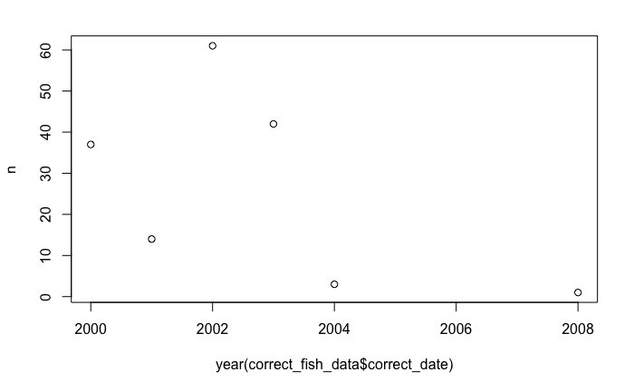

```r
plot(year_count)
```

Remove all entries that below to a year for which there are less than 5 entries E.g. there is only one entry for 2008, so we can remove it. Save the data to a new tibble

```r
large_date_sample_data
```

| correct_date | length | age | maturity | stage | sample_year |
| --- | --- | --- | --- | --- | --- |
| 2003-09-01 14:00:00 | 31 | 10 | Immature | 1 | 2003 |
| 2002-10-06 14:00:00 | 32 | 6 | Immature | 1 | 2002 |
| 2000-07-17 14:00:00 | 32 | 11 | Immature | 1 | 2000 |
| 2001-06-10 14:00:00 | 32 | 11 | Immature | 2 | 2001 |
| 2000-08-07 14:00:00 | 32 | 13 | Immature | 2 | 2000 |
| 2003-10-03 14:00:00 | 33 | 9 | Immature | 1 | 2003 |
| 2000-07-16 14:00:00 | 33 | 10 | Immature | 1 | 2000 |
| 2002-08-17 14:00:00 | 34 | 8 | Immature | 1 | 2002 |
| 2000-07-11 14:00:00 | 34 | 10 | Immature | 1 | 2000 |
| 2000-07-24 14:00:00 | 34 | 11 | Immature | 1 | 2000 |

[output cut: 144 more lines]

```r
# WHY DOESN"T THIS WORK?!
correct_fish_data %>%
  group_by(year(correct_fish_data$correct_date)) %>%
  count() %>%
  filter(n > 5) %>%
  mutate(ungroup(year(correct_fish_data$correct_date)))
```

```
Error: Problem with `mutate()` input `..1`.
ℹ `..1 = ungroup(year(correct_fish_data$correct_date))`.
x no applicable method for 'ungroup' applied to an object of class "c('double', 'numeric')"
ℹ The error occurred in group 1: year(correct_fish_data$correct_date) = 2000.
Run `rlang::last_error()` to see where the error occurred.
```

```r
correct_fish_data %>% filter(correct_fish_data$correct_date, )
```

Count the number of entries and make sure there are less observations

```r
count(large_date_sample_data)
```

| n |
| --- |
| 154 |

Model the fish maturity using the fish length

i.e. predict maturity from the lengh data You can make any changes to the data needed to build this model

```r
numeric_maturity = function(x) {
    if(x == "Mature"){
      1
    }else{
      0
    }
}
numeric_maturity("Mature")
```

```
[1] 1
```

```r
numeric_maturity("Immature")
```

```
[1] 0
```

```r
numeric_maturity("NA")
```

```
[1] 0
```

```r
?mapply
```

```r
mapply(numeric_maturity,large_date_sample_data$maturity)
```

```
Error in if (x == "Mature") { : missing value where TRUE/FALSE needed
```

Generate a plot to show the data and the fit of the model (sigmoid)

What is the length at which the probability of picking a mature fish is 0.5? You can eyeball it or can you compute it formally from the logistic regression

Add an era column to your dataset such that

era has the value “pre_2000” if the year of the observation is pre 2002 era has the value “era2002 and after” otherwise Hint: Check the if_else in dplyr

https://dplyr.tidyverse.org/reference/if_else.html Bonus: implement this operation using a pipeline and mutate

You suspected that some major environmental stressor that occurred in 2002 had an impact on the fish length and maturity

Build a logistic regression for maturity as an outcome using era and length as predictive variables

Make sure your formula accounts for interactions Use an ANOVA to test whether maturity is a function of both length and era

Does the maturity differ between the two eras? i.e. is the era model coefficient significant?

Final note: This practical is inspired from: http://derekogle.com/IFAR/supplements/maturity/index.html#fitting-the-logistic-regression-model

The link above contains most answers, so please do not read until you are done with this practical.